# Data Visualization Using Seaborn Package

Here we will see how to utilise python for analyising data.

## Following Plots are created using seaborn package

1. Distplot - Meant for showing Histogram and Kernel Density Estimation (Sum of all Gaussian Curves + RugPlots)
2. Jointplot - Generates Histogram and Scatterplot together.
3. Pairplot - Multiple Plots Together
4. KDEPLOT - Kernel Density Estimation Plot
5. Facet Grid Plots

```python
import pandas as pd
import numpy as np
import matplotlib.pyplot as plt
import seaborn as sns
```

```python
# this allows to see the plot in Jupyter Notebook
%matplotlib inline
```

```python
# Use NUMPY to create arrays.
# linspace will return values from 0 to 5 with 11 values
x = np.linspace(0,5,11)
```

```python
print(x)
```

```
[0.  0.5 1.  1.5 2.  2.5 3.  3.5 4.  4.5 5. ]
```

```python
y = x**2
```

```python
y
```

```
array([ 0.  ,  0.25,  1.  ,  2.25,  4.  ,  6.25,  9.  , 12.25, 16.  ,
       20.25, 25.  ])
```

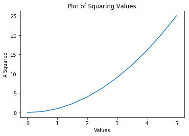

```python
# Functional Way
plt.plot(x,y)
plt.ylabel("X Squared"), plt.xlabel("Values"),plt.title("Plot of Squaring Values")
plt.show()
```

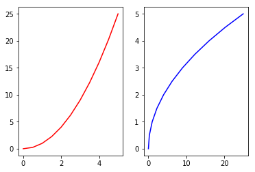

```python
# Lets Create Multiplots
plt.subplot(1,2,1)
plt.plot(x,y,"r")

plt.subplot(1,2,2)
plt.plot(y,x,"b")

plt.show()
```

### Distplot

seaborn.distplot - Flexibly plot a univariate distribution of observations. This function combines the matplotlib hist function and plot the estimated PDF over the data. The calculation of bin size is automatic here.

The most convenient way to take a quick look at a univariate distribution in seaborn is the distplot() function. By default, this will draw a histogram and fit a kernel density estimate (KDE).

```python
auto = pd.read_csv("~/Downloads/Automobile.csv")
```

```python
auto.head()
```

|  | symboling | normalized_losses | make | fuel_type | aspiration | number_of_doors | body_style | drive_wheels | engine_location | wheel_base | ... | engine_size | fuel_system | bore | stroke | compression_ratio | horsepower | peak_rpm | city_mpg | highway_mpg | price |
| --- | --- | --- | --- | --- | --- | --- | --- | --- | --- | --- | --- | --- | --- | --- | --- | --- | --- | --- | --- | --- | --- |
| 0 | 3 | 168 | alfa-romero | gas | std | two | convertible | rwd | front | 88.6 | ... | 130 | mpfi | 3.47 | 2.68 | 9.0 | 111 | 5000 | 21 | 27 | 13495 |
| 1 | 3 | 168 | alfa-romero | gas | std | two | convertible | rwd | front | 88.6 | ... | 130 | mpfi | 3.47 | 2.68 | 9.0 | 111 | 5000 | 21 | 27 | 16500 |
| 2 | 1 | 168 | alfa-romero | gas | std | two | hatchback | rwd | front | 94.5 | ... | 152 | mpfi | 2.68 | 3.47 | 9.0 | 154 | 5000 | 19 | 26 | 16500 |
| 3 | 2 | 164 | audi | gas | std | four | sedan | fwd | front | 99.8 | ... | 109 | mpfi | 3.19 | 3.40 | 10.0 | 102 | 5500 | 24 | 30 | 13950 |
| 4 | 2 | 164 | audi | gas | std | four | sedan | 4wd | front | 99.4 | ... | 136 | mpfi | 3.19 | 3.40 | 8.0 | 115 | 5500 | 18 | 22 | 17450 |

5 rows × 26 columns

```python
# Importing seaborn Package

import seaborn as sns
```

```
AxesSubplot(0.125,0.125;0.775x0.755)
```

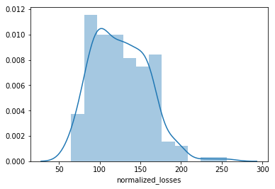

```python
# Distplot
print(sns.distplot(auto["normalized_losses"]))
```

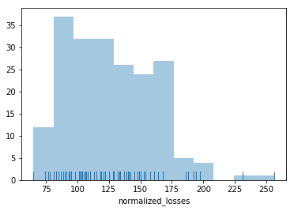

```python
# Histogram of the Same Variable without PDF
sns.distplot(auto["normalized_losses"], kde=False, rug=True)
```

### Histogram

A histogram represents the distribution of data by forming bins along the range of the data and then drawing bars to show the number of observations that fall in each bin.

```python
auto["normalized_losses"].describe()
```

```
count    201.000000
mean     125.189055
std       33.572966
min       65.000000
25%      101.000000
50%      122.000000
75%      150.000000
max      256.000000
Name: normalized_losses, dtype: float64
```

```python
auto.isna().sum()
```

```
symboling              0
normalized_losses      0
make                   0
fuel_type              0
aspiration             0
number_of_doors        0
body_style             0
drive_wheels           0
engine_location        0
wheel_base             0
length                 0
width                  0
height                 0
curb_weight            0
engine_type            0
number_of_cylinders    0
engine_size            0
fuel_system            0
bore                   0
stroke                 0
compression_ratio      0
horsepower             0
peak_rpm               0
city_mpg               0
highway_mpg            0
price                  0
dtype: int64
```

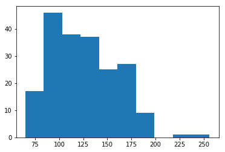

```python
plt.hist(auto["normalized_losses"])
```

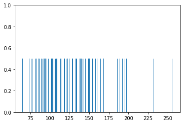

```python
sns.rugplot(auto["normalized_losses"], height=.5)
```

## Bivariate plots - Cont Vs Cont

A bivariate plot is created using jointplots.

A pariplot is used to create scatterplot and histograms between the different numerical variables.

## Bivariate plots - Categorical Variables

A Bivariate categorical var plot is created using stripplot.

## Scatterplots

The most familiar way to visualize a bivariate distribution is a scatterplot, where each observation is shown with point at the x and y values.

You can draw a scatterplot with the matplotlib plt.scatter function, and it is also the default kind of plot shown by the jointplot() function:

sns.jointplot() - It generates scatterplot and histogram together

```python
tips = sns.load_dataset("tips")
```

```python
tips.head()
```

|  | total_bill | tip | sex | smoker | day | time | size |
| --- | --- | --- | --- | --- | --- | --- | --- |
| 0 | 16.99 | 1.01 | Female | No | Sun | Dinner | 2 |
| 1 | 10.34 | 1.66 | Male | No | Sun | Dinner | 3 |
| 2 | 21.01 | 3.50 | Male | No | Sun | Dinner | 3 |
| 3 | 23.68 | 3.31 | Male | No | Sun | Dinner | 2 |
| 4 | 24.59 | 3.61 | Female | No | Sun | Dinner | 4 |

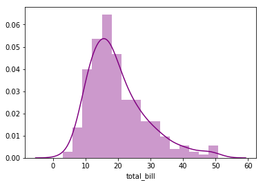

```python
# Univariate Analysis

sns.distplot(tips["total_bill"], bins=16, color="purple")

# Calculation of Bin is Sqrt of Row Count
#np.sqrt(244).round() ; tips.shape()
```

```python
tips.info()
```

```
<class 'pandas.core.frame.DataFrame'>
RangeIndex: 244 entries, 0 to 243
Data columns (total 7 columns):
total_bill    244 non-null float64
tip           244 non-null float64
sex           244 non-null category
smoker        244 non-null category
day           244 non-null category
time          244 non-null category
size          244 non-null int64
dtypes: category(4), float64(2), int64(1)
memory usage: 7.2 KB
```

### Jointplot

A joint plot shows the histogram and scatterplot together. These two can be shown separately as histogram and Tips

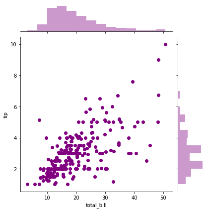

```python
# Jointplot - Meant for Bivariate Distribution

# Syntax - sns.jointplot(x = , y = , data = ) # Generates Histogram and Scatterplot together.

sns.jointplot(x = "total_bill", y = "tip", data = tips, color="purple")
```

### Jointplot :: kind ="hex"

The bivariate analogue of a histogram is known as a “hexbin” plot, because it shows the counts of observations that fall within hexagonal bins. This plot works best with relatively large datasets. Also known as Hexbin Plots

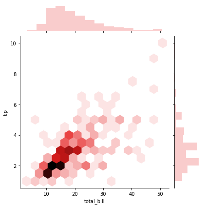

```python
# kind : { "scatter" | "reg" | "resid" | "kde" | "hex" }
sns.jointplot(x = "total_bill", y = "tip", data = tips, kind ="hex" ,color="lightcoral")

# certain points make it darker and lesser points make it lighter
# reg - scatterplot with regression line. The best line fit to the scatter point data
# kde = two dimensional KDE. Shows density where the points match up the most.
```

### Jointplot :: kind ="kde"

It is also possible to use the kernel density estimation to visualize a bivariate distribution. In seaborn, this kind of plot is shown with a contour plot and is available as a style in jointplot().

A Contour plot (sometimes called Level Plots) are a way to show a three-dimensional surface on a two-dimensional plane. It graphs two predictor variables X Y on the y-axis and a response variable Z as contours.

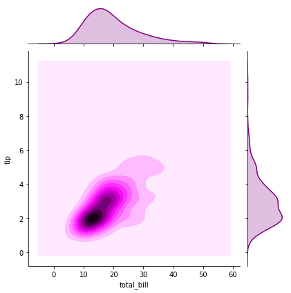

```python
sns.jointplot(x = tips["total_bill"], y = tips["tip"],kind = "kde", color="purple") # contour plot
```